# Estimating K600 from streammetabolizer for GBL

Kelly Loria

2025-01-31

### Background

This is a small, turbulent, shaded stream with a fair amount of fine particulate organic matter.

#### Identifying reasonable modeled estimates of K600

We then ran normal pooling on k600 in stream metabolizer model: `b_Kb_oipi_tr_plrckm.stan` to get modeled K600 to see if we could resolve the negative correlation between ER and K600. Priors on `K600_lnQ_nodes_meanlog` were set as 5 bins based on `rnorm(1000, mean = logQ_mean, sd = logQ_sd)` centered around the mean and logQ values 1-2 sd away from the mean.

##### Load GBL versions of metab data from different model segments with normal prior for gas exchange.

We chose segments of time where we believe GPP occurred and was greater than 0. These chunks of time are from a previous model where we binned flow and incorporated measured and estimated K600 priors from gas exchange measurements a the reach.

### Metabolism segements with CIs

Where GPP is in blue and ER is in orange.

#### 2021 re-run with better binning

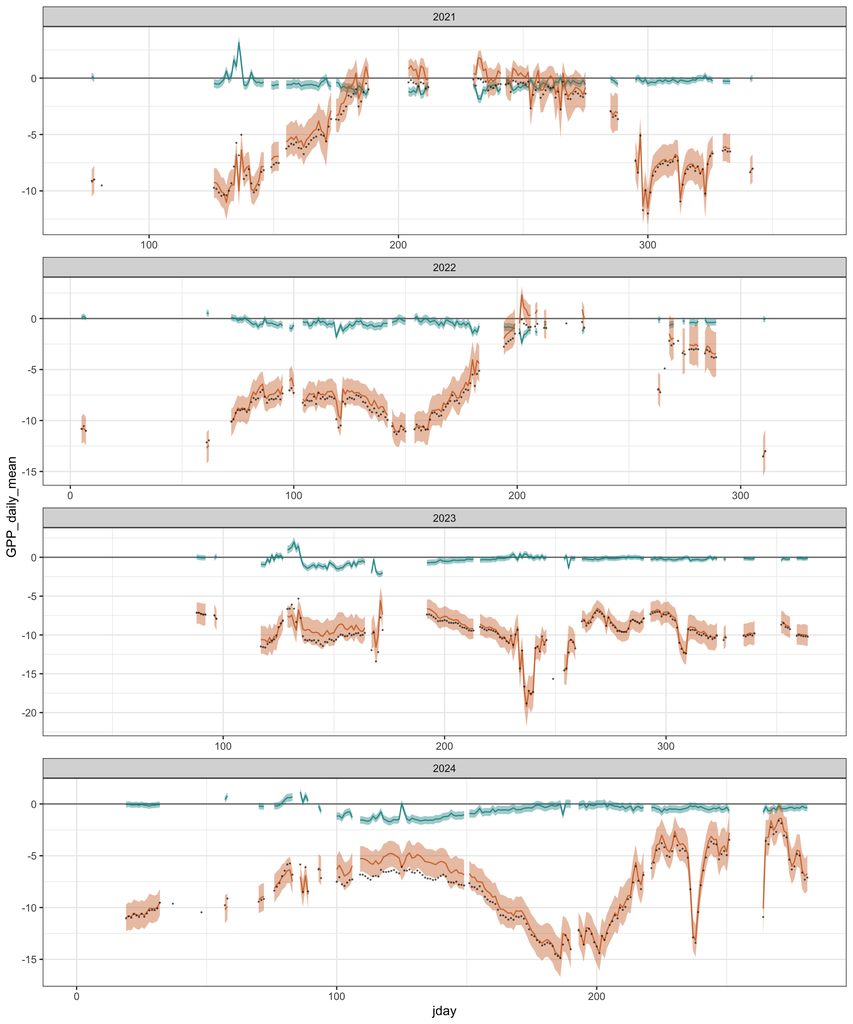

## Checking model convergence

Make sure the chains converged; all r-hat values were well below 1.05 (the red line) for GPP, ER, and K600. The blue lines are the mean for each parameter.

** Not all all segments had great convergence.

### 2021 re-run rhats on GPP and ER

K600 was already filtered (< 1.05).

```r
k600.rhat <- mean(na.omit(met.full$K600_daily_Rhat))
k600.rhat
```

```
## [1] 1.013708
```

```r
GPP.rhat <- mean(na.omit(met.full$GPP_Rhat))
GPP.rhat
```

```
## [1] 1.001413
```

```r
ER.rhat <- mean(na.omit(met.full$ER_Rhat))
ER.rhat
```

```
## [1] 1.012106
```

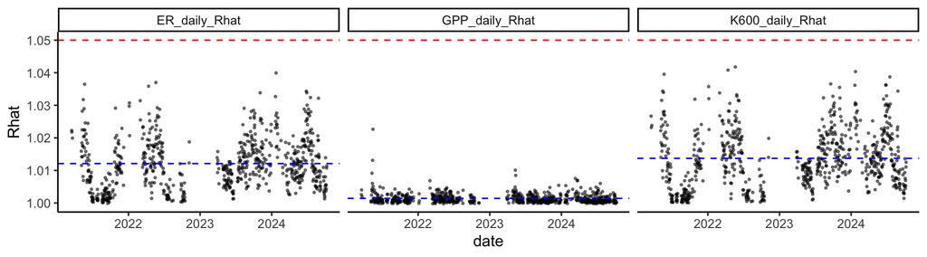

[output not shown]

```r
# Create a dataframe for the vertical lines
rhat_lines <- data.frame(
  Param = c("K600_daily_Rhat", "GPP_daily_Rhat", "ER_daily_Rhat"),
  yintercept = c(k600.rhat, GPP.rhat, ER.rhat)
)

met.full %>%
  select(date, GPP_daily_Rhat, ER_daily_Rhat, K600_daily_Rhat) %>%
  pivot_longer(2:4, values_to = "Rhat", names_to = "Param") %>%
  ggplot(aes(x = date, y = Rhat), col=lab) +
  geom_hline(yintercept = 1.05, col = "red", lty = 2) +
  geom_point(size = 0.5, alpha = 0.5) +
  geom_hline(data = rhat_lines, aes(yintercept = yintercept), col = "blue", lty = 2) +
  theme_classic() +
  facet_wrap(~Param, ncol = 3)
```

## Looking at the K600 and ER relationships from segements with normal K600 pooling

Here is the normal pooling run configuration: **bayes_specs_new**

`bayes_name_new <- mm_name(type = 'bayes', pool_K600 = "normal", err_obs_iid = TRUE, err_proc_iid = TRUE, ode_method = "trapezoid", deficit_src = 'DO_mod', engine = 'stan')`

Where each “lab” segment was run as individual model with the `K600_lnQ_nodes_meanlog` adjusted to match streamline in cms during that time.

### K-ER, K-Q, general K600 trends

```r
ker <- ggplot(met.df, aes(x = K600_daily_mean, y = ER_daily_mean, col = as.factor(lab)))+
  geom_point(size = 2)+
  theme_bw()+ geom_smooth(method="lm", se=F, color="grey50") +
  scale_color_viridis_d(option = "inferno") +  theme(legend.position = "null")


KER_cor <- round(cor(met.df$ER_daily_mean, met.df$K600_daily_mean, use = "complete.obs"),3)
print(KER_cor)
```

```
## [1] -0.933
```

```r
KGPP_cor <-round(cor(met.df$GPP_daily_mean, met.df$K600_daily_mean, use = "complete.obs"),3)
print(KGPP_cor)
```

```
## [1] -0.074
```

```r
kgpp <- ggplot(met.df, aes(y = K600_daily_mean, x = GPP_daily_mean, col = as.factor(lab)))+
  geom_point(size = 2)+  geom_smooth(method="lm", se=F, color="grey50", lty="dashed") +
  theme_bw()+
  scale_color_viridis_d(option = "inferno") +
  theme(legend.position = "null")

kyear <- met.df %>%
ggplot(aes(x = as.factor(year), y = K600_daily_mean, fill = as.factor(lab), col = as.factor(lab)))+
    geom_hline(yintercept = 10, lty = 2)+
  geom_boxplot(alpha = 0.8)+
  theme_bw()+
  scale_fill_viridis_d(option ="inferno") +  # Use _d for discrete
  scale_color_viridis_d(option = "inferno") +
  theme(axis.text.x = element_text(angle = 90, hjust = 1))

mod.env.ag <- input_dat%>%
  mutate(date= as.Date(solar.time))%>%
  group_by(date) %>%
  dplyr:: summarise(
    DO.obs = mean(DO.obs, na.rm=T),
    DO.sat = mean(DO.sat, na.rm=T),
    depth = mean(depth, na.rm=T),
    temp.water = mean(temp.water, na.rm=T),
    light = mean(light, na.rm=T),
    discharge =  mean(discharge, na.rm=T))


k.q <- met.df %>%
  left_join(mod.env.ag, by = "date") %>%
  ggplot(aes(x = discharge, y = K600_daily_mean, col = lab))+
  geom_point( size = 2)+ geom_smooth(method="lm", se=F, color="grey50", lty="dashed") +
  theme_bw()+
  #scale_x_log10(limits = c(20, 800))+
   scale_color_viridis_d(option = "inferno")

mean_k_mod <- mean(met.df$K600_daily_mean)
mean_k_mod
```

```
## [1] 15.3487
```

```r
mean_k_measure <- mean(measured_K$K600)
mean_k_measure
```

```
## [1] 39.53105
```

```r
possibleK <- (mean_k_mod + mean_k_measure)/2
possibleK
```

```
## [1] 27.43988
```

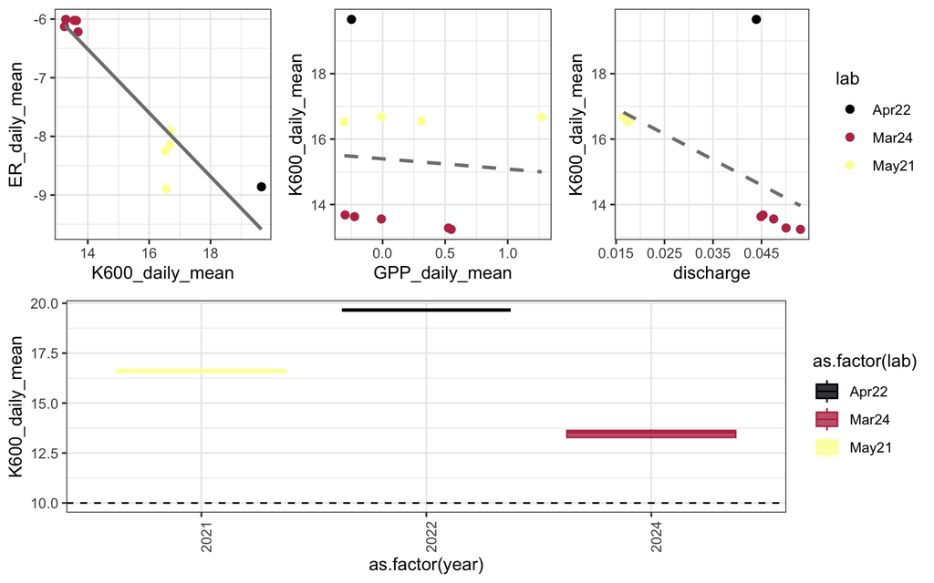

```r
p1 <- plot_grid(ker, kgpp, k.q, rel_widths =c(0.3, 0.3, 0.4), ncol = 3)
plot_grid(p1, kyear, ncol = 1)
```

### Compared modeled and measured K600

Plots for (1) measured v modeled K600 and flow and (2) logK600 and log(flow+1).

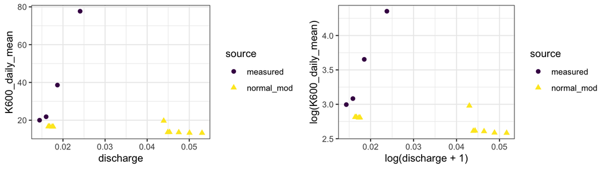

### 2021 re-run test with binned K600

```r
met.full21_clean <- met.full %>%
  filter(GPP_daily_Rhat<1.05)%>%
  filter(GPP_97.5pct>0)%>%
  filter(ER_daily_Rhat<1.05) %>%
  filter(ER_2.5pct<0)%>%
  filter(K600_daily_Rhat<1.05)

ker <- ggplot(met.full21_clean, aes(x = K600_daily_mean, y = ER_daily_mean, col = as.factor(lab)))+
  geom_point(size = 2)+
  theme_bw()+ geom_smooth(method="lm", se=F, color="grey50") +
  scale_color_viridis_d(option = "inferno") +  theme(legend.position = "null")


KER_cor <- round(cor(met.full21_clean$ER_daily_mean, met.full21_clean$K600_daily_mean, use = "complete.obs"),3)
print(KER_cor)
```

```
## [1] -0.759
```

```r
KGPP_cor <-round(cor(met.full21_clean$GPP_daily_mean, met.full21_clean$K600_daily_mean, use = "complete.obs"),3)
print(KGPP_cor)
```

```
## [1] 0.073
```

```r
kgpp <- ggplot(met.full21_clean, aes(y = K600_daily_mean, x = GPP_daily_mean, col = as.factor(lab)))+
  geom_point(size = 2)+  geom_smooth(method="lm", se=F, color="grey50", lty="dashed") +
  theme_bw()+
  scale_color_viridis_d(option = "inferno") +
  theme(legend.position = "null")

kyear <- met.full21_clean %>%
ggplot(aes(x = as.factor(year), y = K600_daily_mean, fill = as.factor(lab), col = as.factor(lab)))+
    geom_hline(yintercept = 10, lty = 2)+
  geom_boxplot(alpha = 0.8)+
  theme_bw()+
  scale_fill_viridis_d(option ="inferno") +  # Use _d for discrete
  scale_color_viridis_d(option = "inferno") +
  theme(axis.text.x = element_text(angle = 90, hjust = 1))

mod.env.ag <- input_dat%>%
  mutate(date= as.Date(solar.time))%>%
  group_by(date) %>%
  dplyr:: summarise(
    DO.obs = mean(DO.obs, na.rm=T),
    DO.sat = mean(DO.sat, na.rm=T),
    depth = mean(depth, na.rm=T),
    temp.water = mean(temp.water, na.rm=T),
    light = mean(light, na.rm=T),
    discharge =  mean(discharge, na.rm=T))


k.q <- met.full21_clean %>%
  left_join(mod.env.ag, by = "date") %>%
  ggplot(aes(x = discharge, y = K600_daily_mean, col = lab))+
  geom_point( size = 2)+ geom_smooth(method="lm", se=F, color="grey50", lty="dashed") +
  theme_bw()+
  #scale_x_log10(limits = c(20, 800))+
   scale_color_viridis_d(option = "inferno")



mean_k_mod <- mean(met.full21_clean$K600_daily_mean)
mean_k_mod
```

```
## [1] 16.93494
```

```r
mean_k_measure <- mean(measured_K$K600)
mean_k_measure
```

```
## [1] 39.53105
```

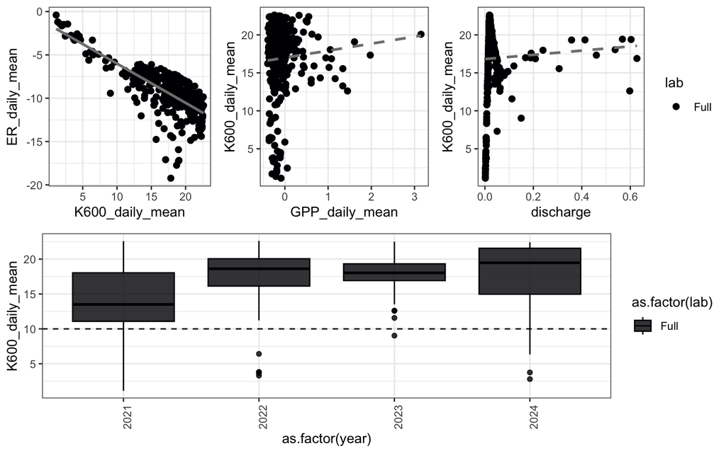

```r
p1 <- plot_grid(ker, kgpp, k.q, rel_widths =c(0.3, 0.3, 0.4), ncol = 3)
plot_grid(p1, kyear, ncol = 1)
```

## Final thoughts.

### Final cleaned model output:

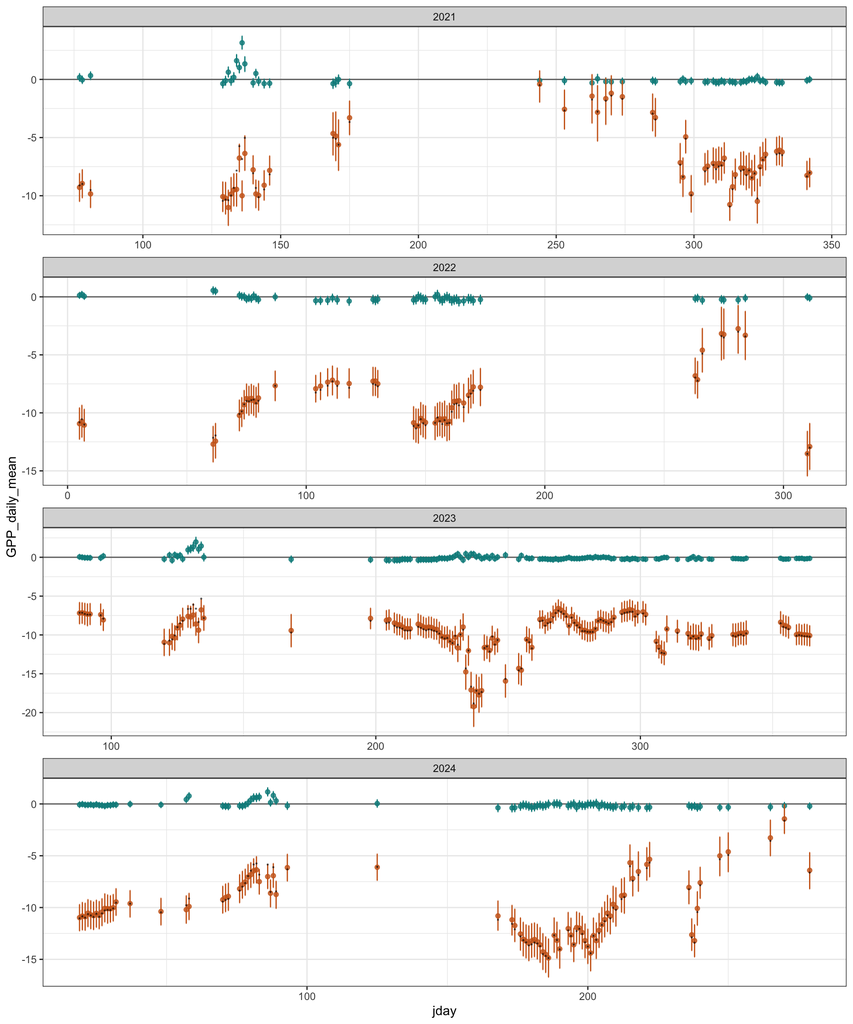